# Part3_Classification

Quincey Niu

2023-04-24

## Load packages

```r
library(tidyverse)
library(rstanarm)
library(caret)
```

## Read data

```r
df <- readr::read_csv("paint_project_train_data.csv", col_names = TRUE)
df %>% pull(outcome) %>% class()
```

```
## [1] "numeric"
```

```r
df %>% count(outcome)
```

```
## # A tibble: 2 × 2
##   outcome     n
##     <dbl> <int>
## 1       0   644
## 2       1   191
```

```r
dfiiiA <- df %>%
  select(-response)

dfiiiA %>% glimpse()
```

```
## Rows: 835
## Columns: 7
## $ R          <dbl> 172, 26, 172, 28, 170, 175, 90, 194, 171, 122, 0, 88, 144, …
## $ G          <dbl> 58, 88, 94, 87, 66, 89, 78, 106, 68, 151, 121, 140, 82, 163…
## $ B          <dbl> 62, 151, 58, 152, 58, 65, 136, 53, 107, 59, 88, 58, 132, 50…
## $ Lightness  <chr> "dark", "dark", "dark", "dark", "dark", "dark", "dark", "da…
## $ Saturation <chr> "bright", "bright", "bright", "bright", "bright", "bright",…
## $ Hue        <dbl> 4, 31, 8, 32, 5, 6, 34, 10, 1, 21, 24, 22, 36, 16, 26, 12, …
## $ outcome    <dbl> 1, 1, 1, 0, 0, 0, 0, 0, 0, 0, 0, 0, 0, 0, 0, 0, 0, 0, 1, 1,…
```

```r
ctrl_roc <- trainControl(method = "repeatedcv",
                         number = 5,
                         repeats = 3,
                         summaryFunction = twoClassSummary,
                         classProbs = TRUE,
                         savePredictions = TRUE)

metric_roc <- "ROC"
```

## Fitting models using glm()

Intercept-only model

```r
mod1 <- glm(outcome ~ 1, data = dfiiiA, family = binomial())
summary(mod1)
```

```
##
## Call:
## glm(formula = outcome ~ 1, family = binomial(), data = dfiiiA)
##
## Deviance Residuals:
##     Min       1Q   Median       3Q      Max
## -0.7207  -0.7207  -0.7207  -0.7207   1.7176
##
## Coefficients:
##             Estimate Std. Error z value Pr(>|z|)
## (Intercept) -1.21543    0.08239  -14.75   <2e-16 ***
## ---
## Signif. codes:  0 '***' 0.001 '**' 0.01 '*' 0.05 '.' 0.1 ' ' 1
##
## (Dispersion parameter for binomial family taken to be 1)
##
##     Null deviance: 898.05  on 834  degrees of freedom
## Residual deviance: 898.05  on 834  degrees of freedom
## AIC: 900.05
##
## Number of Fisher Scoring iterations: 4
```

Categorical variables only - linear additive

```r
mod2 <- glm(outcome ~ Lightness + Saturation, data = dfiiiA, family = binomial())
summary(mod2)
```

```
##
## Call:
## glm(formula = outcome ~ Lightness + Saturation, family = binomial(),
##     data = dfiiiA)
##
## Deviance Residuals:
##     Min       1Q   Median       3Q      Max
## -1.8732  -0.6779  -0.4438  -0.2555   2.4151
##
## Coefficients:
##                    Estimate Std. Error z value Pr(>|z|)
## (Intercept)         -2.6460     0.4672  -5.664 1.48e-08 ***
## Lightnessdeep       -0.6513     0.3551  -1.834  0.06665 .
## Lightnesslight      -0.6021     0.3514  -1.714  0.08660 .
## Lightnessmidtone    -0.2046     0.3363  -0.608  0.54300
## Lightnesspale       -0.2148     0.3348  -0.642  0.52118
## Lightnesssaturated  -0.8739     0.3668  -2.382  0.01721 *
## Lightnesssoft       -0.1694     0.3340  -0.507  0.61200
## Saturationgray       4.2105     0.4943   8.519  < 2e-16 ***
## Saturationmuted      0.5472     0.5337   1.025  0.30521
## Saturationneutral    2.3742     0.4613   5.147 2.65e-07 ***
## Saturationpure       1.0741     0.4978   2.158  0.03096 *
## Saturationshaded     1.8918     0.4681   4.041 5.32e-05 ***
## Saturationsubdued    1.5072     0.4790   3.146  0.00165 **
## ---
## Signif. codes:  0 '***' 0.001 '**' 0.01 '*' 0.05 '.' 0.1 ' ' 1
##
## (Dispersion parameter for binomial family taken to be 1)
##
##     Null deviance: 898.05  on 834  degrees of freedom
## Residual deviance: 713.72  on 822  degrees of freedom
## AIC: 739.72
##
## Number of Fisher Scoring iterations: 5
```

Continuous variables only - linear additive

```r
mod3 <- glm(outcome ~ R + G + B + Hue, data = dfiiiA, family = binomial())
summary(mod3)
```

```
##
## Call:
## glm(formula = outcome ~ R + G + B + Hue, family = binomial(),
##     data = dfiiiA)
##
## Deviance Residuals:
##     Min       1Q   Median       3Q      Max
## -1.2701  -0.7464  -0.6489  -0.4347   2.4841
##
## Coefficients:
##              Estimate Std. Error z value Pr(>|z|)
## (Intercept) -0.027962   0.362928  -0.077  0.93859
## R           -0.007848   0.002673  -2.936  0.00333 **
## G           -0.006936   0.004003  -1.733  0.08314 .
## B            0.011524   0.003138   3.673  0.00024 ***
## Hue         -0.024320   0.010469  -2.323  0.02017 *
## ---
## Signif. codes:  0 '***' 0.001 '**' 0.01 '*' 0.05 '.' 0.1 ' ' 1
##
## (Dispersion parameter for binomial family taken to be 1)
##
##     Null deviance: 898.05  on 834  degrees of freedom
## Residual deviance: 868.05  on 830  degrees of freedom
## AIC: 878.05
##
## Number of Fisher Scoring iterations: 4
```

All categorical and continuous variables - linear additive

```r
mod4 <- glm(outcome ~ R + G + B + Lightness + Saturation + Hue, data = dfiiiA, family = binomial())
summary(mod4)
```

```
##
## Call:
## glm(formula = outcome ~ R + G + B + Lightness + Saturation +
##     Hue, family = binomial(), data = dfiiiA)
##
## Deviance Residuals:
##     Min       1Q   Median       3Q      Max
## -1.9208  -0.6728  -0.4173  -0.1731   2.7875
##
## Coefficients:
##                     Estimate Std. Error z value Pr(>|z|)
## (Intercept)        -0.985373   0.919354  -1.072 0.283805
## R                  -0.007936   0.003819  -2.078 0.037691 *
## G                  -0.012101   0.006394  -1.893 0.058411 .
## B                   0.005324   0.005498   0.968 0.332881
## Lightnessdeep      -0.355946   0.417757  -0.852 0.394191
## Lightnesslight      1.171220   1.116949   1.049 0.294367
## Lightnessmidtone    1.035165   0.814135   1.271 0.203554
## Lightnesspale       1.690741   1.180125   1.433 0.151949
## Lightnesssaturated -0.085366   0.596838  -0.143 0.886267
## Lightnesssoft       1.418100   0.990152   1.432 0.152085
## Saturationgray      3.955363   0.511553   7.732 1.06e-14 ***
## Saturationmuted     0.482504   0.540418   0.893 0.371946
## Saturationneutral   2.252350   0.468809   4.804 1.55e-06 ***
## Saturationpure      1.249947   0.512138   2.441 0.014661 *
## Saturationshaded    1.770719   0.475813   3.721 0.000198 ***
## Saturationsubdued   1.429401   0.488789   2.924 0.003452 **
## Hue                -0.002343   0.012250  -0.191 0.848324
## ---
## Signif. codes:  0 '***' 0.001 '**' 0.01 '*' 0.05 '.' 0.1 ' ' 1
##
## (Dispersion parameter for binomial family taken to be 1)
##
##     Null deviance: 898.05  on 834  degrees of freedom
## Residual deviance: 696.56  on 818  degrees of freedom
## AIC: 730.56
##
## Number of Fisher Scoring iterations: 5
```

Interaction of categorical inputs with all continuous inputs main effects

```r
mod5 <- glm(outcome ~ Lightness:R + Lightness:G + Lightness:B + Saturation:R + Saturation:G + Saturation:B + Hue:R + Hue:G + Hue:B, data = dfiiiA, family = binomial())
summary(mod5)
```

```
##
## Call:
## glm(formula = outcome ~ Lightness:R + Lightness:G + Lightness:B +
##     Saturation:R + Saturation:G + Saturation:B + Hue:R + Hue:G +
##     Hue:B, family = binomial(), data = dfiiiA)
##
## Deviance Residuals:
##      Min        1Q    Median        3Q       Max
## -2.30737  -0.58973  -0.27203  -0.06603   3.12080
##
## Coefficients:
##                        Estimate Std. Error z value Pr(>|z|)
## (Intercept)           1.1188604  1.3721044   0.815 0.414824
## Lightnessdark:R       0.0294584  0.0107067   2.751 0.005934 **
## Lightnessdeep:R       0.0152664  0.0133719   1.142 0.253591
## Lightnesslight:R      0.0158696  0.0317847   0.499 0.617578
## Lightnessmidtone:R   -0.0072492  0.0153973  -0.471 0.637774
## Lightnesspale:R       0.1164360  0.0458782   2.538 0.011151 *
## Lightnesssaturated:R  0.0023079  0.0144237   0.160 0.872873
## Lightnesssoft:R      -0.0190743  0.0210383  -0.907 0.364594
## Lightnessdark:G      -0.0107098  0.0218949  -0.489 0.624739
## Lightnessdeep:G       0.0088657  0.0273931   0.324 0.746206
## Lightnesslight:G      0.0757821  0.0493319   1.536 0.124497
## Lightnessmidtone:G    0.0702584  0.0291227   2.412 0.015844 *
## Lightnesspale:G      -0.0082211  0.0624159  -0.132 0.895209
## Lightnesssaturated:G  0.0436086  0.0280112   1.557 0.119511
## Lightnesssoft:G       0.0873815  0.0370911   2.356 0.018480 *
## Lightnessdark:B      -0.0709770  0.0227817  -3.116 0.001836 **
## Lightnessdeep:B      -0.0734534  0.0244660  -3.002 0.002680 **
## Lightnesslight:B     -0.1268103  0.0309196  -4.101 4.11e-05 ***
## Lightnessmidtone:B   -0.0986578  0.0240886  -4.096 4.21e-05 ***
## Lightnesspale:B      -0.1418858  0.0378509  -3.749 0.000178 ***
## Lightnesssaturated:B -0.0899645  0.0242563  -3.709 0.000208 ***
## Lightnesssoft:B      -0.1004452  0.0260821  -3.851 0.000118 ***
## R:Saturationgray      0.0116886  0.0378417   0.309 0.757413
## R:Saturationmuted    -0.0078160  0.0106352  -0.735 0.462390
## R:Saturationneutral  -0.0007260  0.0180378  -0.040 0.967894
## R:Saturationpure     -0.0057533  0.0089746  -0.641 0.521479
## R:Saturationshaded   -0.0077635  0.0144460  -0.537 0.590979
## R:Saturationsubdued  -0.0027689  0.0111724  -0.248 0.804259
```

[output cut: 10 more lines]

```
## B:Saturationshaded    0.0071871  0.0169730   0.423 0.671971
## B:Saturationsubdued   0.0269353  0.0167381   1.609 0.107569
## R:Hue                -0.0013752  0.0004650  -2.957 0.003105 **
## G:Hue                -0.0015160  0.0008674  -1.748 0.080502 .
## B:Hue                 0.0029767  0.0007453   3.994 6.50e-05 ***
## ---
## Signif. codes:  0 '***' 0.001 '**' 0.01 '*' 0.05 '.' 0.1 ' ' 1
##
## (Dispersion parameter for binomial family taken to be 1)
##
##     Null deviance: 898.05  on 834  degrees of freedom
## Residual deviance: 601.24  on 792  degrees of freedom
## AIC: 687.24
##
## Number of Fisher Scoring iterations: 6
```

Add categorical inputs to all main effect and all pairwise interactions of continuous inputs

```r
mod6 <- glm(outcome ~ R + G + B + Lightness + Saturation + Hue + R:Lightness + R:Saturation + R:Hue + G:Lightness + G:Saturation + G:Hue + B:Lightness + B:Saturation + B:Hue, data = dfiiiA, family = binomial())
summary(mod6)
```

```
##
## Call:
## glm(formula = outcome ~ R + G + B + Lightness + Saturation +
##     Hue + R:Lightness + R:Saturation + R:Hue + G:Lightness +
##     G:Saturation + G:Hue + B:Lightness + B:Saturation + B:Hue,
##     family = binomial(), data = dfiiiA)
##
## Deviance Residuals:
##     Min       1Q   Median       3Q      Max
## -2.2710  -0.5332  -0.1994  -0.0046   4.1879
##
## Coefficients:
##                        Estimate Std. Error z value Pr(>|z|)
## (Intercept)           -9.266015   4.360533  -2.125 0.033589 *
## R                      0.098798   0.027469   3.597 0.000322 ***
## G                     -0.006958   0.029482  -0.236 0.813419
## B                     -0.082688   0.032610  -2.536 0.011224 *
## Lightnessdeep         13.672877   5.001997   2.733 0.006267 **
## Lightnesslight         0.315244   8.350288   0.038 0.969885
## Lightnessmidtone      -1.921880   4.053019  -0.474 0.635368
## Lightnesspale        -37.805562  10.554634  -3.582 0.000341 ***
## Lightnesssaturated    -7.765094   3.629440  -2.139 0.032397 *
## Lightnesssoft         -1.525519   4.852480  -0.314 0.753233
## Saturationgray        11.755959   3.198664   3.675 0.000238 ***
## Saturationmuted        3.048156   2.652665   1.149 0.250518
## Saturationneutral     10.140126   2.880620   3.520 0.000431 ***
## Saturationpure         3.919622   2.767512   1.416 0.156688
## Saturationshaded       8.961346   2.689763   3.332 0.000863 ***
## Saturationsubdued      7.226781   2.610770   2.768 0.005639 **
## Hue                   -0.099875   0.076782  -1.301 0.193341
## R:Lightnessdeep       -0.057393   0.018728  -3.064 0.002180 **
## R:Lightnesslight      -0.019636   0.035972  -0.546 0.585155
## R:Lightnessmidtone    -0.047026   0.017834  -2.637 0.008367 **
## R:Lightnesspale        0.145756   0.053188   2.740 0.006136 **
## R:Lightnesssaturated  -0.023324   0.016069  -1.451 0.146656
## R:Lightnesssoft       -0.058017   0.023511  -2.468 0.013598 *
## R:Saturationgray      -0.101828   0.051430  -1.980 0.047711 *
## R:Saturationmuted     -0.017165   0.017247  -0.995 0.319622
## R:Saturationneutral   -0.038957   0.024522  -1.589 0.112135
## R:Saturationpure      -0.028479   0.015868  -1.795 0.072705 .
```

[output cut: 24 more lines]

```
## B:Saturationneutral   -0.041775   0.026561  -1.573 0.115766
## B:Saturationpure      -0.025926   0.022341  -1.160 0.245852
## B:Saturationshaded    -0.033738   0.025332  -1.332 0.182913
## B:Saturationsubdued   -0.001238   0.024818  -0.050 0.960230
## B:Hue                  0.006297   0.001189   5.297 1.17e-07 ***
## ---
## Signif. codes:  0 '***' 0.001 '**' 0.01 '*' 0.05 '.' 0.1 ' ' 1
##
## (Dispersion parameter for binomial family taken to be 1)
##
##     Null deviance: 898.05  on 834  degrees of freedom
## Residual deviance: 539.81  on 779  degrees of freedom
## AIC: 651.81
##
## Number of Fisher Scoring iterations: 7
```

Interaction of the categorical inputs with all main effect and all pairwise interactions of continuous inputs

```r
mod7 <- glm(outcome ~ Lightness + Saturation + Hue + Lightness:R + Lightness:G + Lightness:B + Saturation:R + Saturation:G + Saturation:B + Hue:R + Hue:G + Hue:B, data = dfiiiA, family = binomial())
summary(mod7)
```

```
##
## Call:
## glm(formula = outcome ~ Lightness + Saturation + Hue + Lightness:R +
##     Lightness:G + Lightness:B + Saturation:R + Saturation:G +
##     Saturation:B + Hue:R + Hue:G + Hue:B, family = binomial(),
##     data = dfiiiA)
##
## Deviance Residuals:
##     Min       1Q   Median       3Q      Max
## -2.2710  -0.5332  -0.1994  -0.0046   4.1879
##
## Coefficients:
##                        Estimate Std. Error z value Pr(>|z|)
## (Intercept)           -9.266015   4.360533  -2.125 0.033589 *
## Lightnessdeep         13.672877   5.001997   2.733 0.006267 **
## Lightnesslight         0.315244   8.350288   0.038 0.969885
## Lightnessmidtone      -1.921880   4.053019  -0.474 0.635368
## Lightnesspale        -37.805562  10.554634  -3.582 0.000341 ***
## Lightnesssaturated    -7.765094   3.629440  -2.139 0.032397 *
## Lightnesssoft         -1.525519   4.852480  -0.314 0.753233
## Saturationgray        11.755959   3.198664   3.675 0.000238 ***
## Saturationmuted        3.048156   2.652665   1.149 0.250518
## Saturationneutral     10.140126   2.880620   3.520 0.000431 ***
## Saturationpure         3.919622   2.767512   1.416 0.156688
## Saturationshaded       8.961346   2.689763   3.332 0.000863 ***
## Saturationsubdued      7.226781   2.610770   2.768 0.005639 **
## Hue                   -0.099875   0.076782  -1.301 0.193341
## Lightnessdark:R        0.098798   0.027469   3.597 0.000322 ***
## Lightnessdeep:R        0.041405   0.027504   1.505 0.132219
## Lightnesslight:R       0.079162   0.040685   1.946 0.051687 .
## Lightnessmidtone:R     0.051772   0.026705   1.939 0.052541 .
## Lightnesspale:R        0.244554   0.057091   4.284 1.84e-05 ***
## Lightnesssaturated:R   0.075474   0.026621   2.835 0.004580 **
## Lightnesssoft:R        0.040780   0.030687   1.329 0.183881
## Lightnessdark:G       -0.006958   0.029482  -0.236 0.813419
## Lightnessdeep:G       -0.009539   0.045179  -0.211 0.832773
## Lightnesslight:G       0.109658   0.059683   1.837 0.066161 .
## Lightnessmidtone:G     0.119707   0.039266   3.049 0.002299 **
## Lightnesspale:G        0.090008   0.068641   1.311 0.189762
## Lightnesssaturated:G   0.088079   0.037983   2.319 0.020399 *
```

[output cut: 24 more lines]

```
## Saturationshaded:B    -0.033738   0.025332  -1.332 0.182913
## Saturationsubdued:B   -0.001238   0.024818  -0.050 0.960230
## Hue:R                 -0.003541   0.001025  -3.456 0.000548 ***
## Hue:G                 -0.002087   0.001310  -1.593 0.111087
## Hue:B                  0.006297   0.001189   5.297 1.17e-07 ***
## ---
## Signif. codes:  0 '***' 0.001 '**' 0.01 '*' 0.05 '.' 0.1 ' ' 1
##
## (Dispersion parameter for binomial family taken to be 1)
##
##     Null deviance: 898.05  on 834  degrees of freedom
## Residual deviance: 539.81  on 779  degrees of freedom
## AIC: 651.81
##
## Number of Fisher Scoring iterations: 7
```

### Model with basis functions of your choice

```r
library(splines)

# using cubic spline basis function for R variable
mod8 <- glm(outcome ~ ns(R, df = 4) + G + B + Lightness + Saturation + Hue, data = dfiiiA, family = binomial())
summary(mod8)
```

```
##
## Call:
## glm(formula = outcome ~ ns(R, df = 4) + G + B + Lightness + Saturation +
##     Hue, family = binomial(), data = dfiiiA)
##
## Deviance Residuals:
##     Min       1Q   Median       3Q      Max
## -1.9600  -0.6603  -0.4066  -0.1477   2.6014
##
## Coefficients:
##                     Estimate Std. Error z value Pr(>|z|)
## (Intercept)        -0.778966   1.057235  -0.737 0.461247
## ns(R, df = 4)1     -1.380693   0.824848  -1.674 0.094155 .
## ns(R, df = 4)2     -2.703137   0.891405  -3.032 0.002426 **
## ns(R, df = 4)3     -3.094046   1.623716  -1.906 0.056711 .
## ns(R, df = 4)4      1.043817   1.081905   0.965 0.334647
## G                  -0.013603   0.006852  -1.985 0.047122 *
## B                   0.006539   0.005748   1.138 0.255314
## Lightnessdeep      -0.340826   0.429873  -0.793 0.427864
## Lightnesslight      1.131226   1.129650   1.001 0.316636
## Lightnessmidtone    0.956519   0.847915   1.128 0.259285
## Lightnesspale       1.570496   1.193971   1.315 0.188390
## Lightnesssaturated -0.189239   0.627559  -0.302 0.762997
## Lightnesssoft       1.401013   1.009531   1.388 0.165202
## Saturationgray      4.328492   0.541791   7.989 1.36e-15 ***
## Saturationmuted     0.636480   0.548298   1.161 0.245712
## Saturationneutral   2.592966   0.491776   5.273 1.34e-07 ***
## Saturationpure      1.043663   0.520220   2.006 0.044835 *
## Saturationshaded    2.054251   0.493644   4.161 3.16e-05 ***
## Saturationsubdued   1.665960   0.503150   3.311 0.000929 ***
## Hue                 0.005446   0.013211   0.412 0.680182
## ---
## Signif. codes:  0 '***' 0.001 '**' 0.01 '*' 0.05 '.' 0.1 ' ' 1
##
## (Dispersion parameter for binomial family taken to be 1)
##
##     Null deviance: 898.05  on 834  degrees of freedom
## Residual deviance: 686.15  on 815  degrees of freedom
## AIC: 726.15
##
## Number of Fisher Scoring iterations: 5
```

```r
# using exponential transformation for G variable
mod9 <- glm(outcome ~ R + exp(G) + B + Lightness + Saturation + Hue, data = dfiiiA, family = binomial())
summary(mod9)
```

```
##
## Call:
## glm(formula = outcome ~ R + exp(G) + B + Lightness + Saturation +
##     Hue, family = binomial(), data = dfiiiA)
##
## Deviance Residuals:
##     Min       1Q   Median       3Q      Max
## -1.8695  -0.6680  -0.4219  -0.1893   2.6317
##
## Coefficients:
##                       Estimate  Std. Error z value Pr(>|z|)
## (Intercept)         -1.729e+00   8.248e-01  -2.096  0.03605 *
## R                   -1.031e-02   3.528e-03  -2.924  0.00346 **
## exp(G)             -1.184e-105  3.448e-105  -0.343  0.73130
## B                    3.647e-03   5.401e-03   0.675  0.49953
## Lightnessdeep       -5.544e-01   4.002e-01  -1.385  0.16603
## Lightnesslight       1.737e-01   9.736e-01   0.178  0.85840
## Lightnessmidtone     3.329e-01   7.161e-01   0.465  0.64203
## Lightnesspale        6.299e-01   1.022e+00   0.616  0.53780
## Lightnesssaturated  -5.349e-01   5.433e-01  -0.985  0.32482
## Lightnesssoft        5.351e-01   8.632e-01   0.620  0.53531
## Saturationgray       4.069e+00   5.079e-01   8.012 1.13e-15 ***
## Saturationmuted      5.357e-01   5.397e-01   0.993  0.32088
## Saturationneutral    2.314e+00   4.673e-01   4.953 7.32e-07 ***
## Saturationpure       1.118e+00   5.094e-01   2.195  0.02815 *
## Saturationshaded     1.846e+00   4.738e-01   3.897 9.75e-05 ***
## Saturationsubdued    1.506e+00   4.864e-01   3.097  0.00196 **
## Hue                 -6.642e-03   1.208e-02  -0.550  0.58250
## ---
## Signif. codes:  0 '***' 0.001 '**' 0.01 '*' 0.05 '.' 0.1 ' ' 1
##
## (Dispersion parameter for binomial family taken to be 1)
##
##     Null deviance: 898.05  on 834  degrees of freedom
## Residual deviance: 700.15  on 818  degrees of freedom
## AIC: 734.15
##
## Number of Fisher Scoring iterations: 5
```

```r
# using interaction between cubic spline basis function for R variable and Saturation variable
mod10 <- glm(outcome ~ ns(R, df = 4) + G + B + Lightness + Saturation + Hue + ns(R, df = 4):Saturation, data = dfiiiA, family = binomial())
summary(mod10)
```

```
##
## Call:
## glm(formula = outcome ~ ns(R, df = 4) + G + B + Lightness + Saturation +
##     Hue + ns(R, df = 4):Saturation, family = binomial(), data = dfiiiA)
##
## Deviance Residuals:
##     Min       1Q   Median       3Q      Max
## -2.1436  -0.6539  -0.3641   0.0000   2.8956
##
## Coefficients:
##                                    Estimate Std. Error z value Pr(>|z|)
## (Intercept)                       5.668e-01  1.759e+00   0.322   0.7473
## ns(R, df = 4)1                    2.043e-01  2.011e+00   0.102   0.9191
## ns(R, df = 4)2                   -4.882e+00  2.918e+00  -1.673   0.0944 .
## ns(R, df = 4)3                   -3.737e+00  4.536e+00  -0.824   0.4100
## ns(R, df = 4)4                    4.814e+00  3.282e+00   1.467   0.1424
## G                                -1.661e-02  6.941e-03  -2.394   0.0167 *
## B                                -4.133e-03  6.291e-03  -0.657   0.5112
## Lightnessdeep                    -4.437e-02  4.522e-01  -0.098   0.9218
## Lightnesslight                    2.367e+00  1.217e+00   1.945   0.0518 .
## Lightnessmidtone                  2.054e+00  9.198e-01   2.233   0.0256 *
## Lightnesspale                     2.711e+00  1.293e+00   2.097   0.0360 *
## Lightnesssaturated                5.427e-01  6.800e-01   0.798   0.4248
## Lightnesssoft                     2.711e+00  1.091e+00   2.485   0.0130 *
## Saturationgray                   -6.698e-01  5.485e+00  -0.122   0.9028
## Saturationmuted                   1.886e-01  1.938e+00   0.097   0.9224
## Saturationneutral                 3.280e-01  2.720e+00   0.121   0.9040
## Saturationpure                    2.011e-01  1.958e+00   0.103   0.9182
## Saturationshaded                  4.711e+00  2.726e+00   1.728   0.0840 .
## Saturationsubdued                 3.476e+00  2.340e+00   1.485   0.1374
## Hue                               1.502e-02  1.528e-02   0.983   0.3254
## ns(R, df = 4)1:Saturationgray     2.699e+00  4.986e+00   0.541   0.5882
## ns(R, df = 4)2:Saturationgray     6.615e+00  5.036e+00   1.313   0.1891
## ns(R, df = 4)3:Saturationgray     1.434e+01  1.227e+01   1.169   0.2423
## ns(R, df = 4)4:Saturationgray     3.652e+00  8.258e+00   0.442   0.6583
## ns(R, df = 4)1:Saturationmuted   -2.085e+00  2.559e+00  -0.815   0.4153
## ns(R, df = 4)2:Saturationmuted    4.822e+00  5.597e+00   0.861   0.3890
## ns(R, df = 4)3:Saturationmuted   -6.464e+02  1.013e+03  -0.638   0.5234
## ns(R, df = 4)4:Saturationmuted   -9.746e+02  1.511e+03  -0.645   0.5190
## ns(R, df = 4)1:Saturationneutral  1.547e-01  2.848e+00   0.054   0.9567
```

[output cut: 10 more lines]

```
## ns(R, df = 4)4:Saturationshaded  -3.010e+00  3.824e+00  -0.787   0.4312
## ns(R, df = 4)1:Saturationsubdued -3.693e+00  2.548e+00  -1.449   0.1473
## ns(R, df = 4)2:Saturationsubdued  7.656e-01  3.296e+00   0.232   0.8163
## ns(R, df = 4)3:Saturationsubdued -2.826e+00  6.183e+00  -0.457   0.6476
## ns(R, df = 4)4:Saturationsubdued -2.454e+00  3.850e+00  -0.637   0.5239
## ---
## Signif. codes:  0 '***' 0.001 '**' 0.01 '*' 0.05 '.' 0.1 ' ' 1
##
## (Dispersion parameter for binomial family taken to be 1)
##
##     Null deviance: 898.05  on 834  degrees of freedom
## Residual deviance: 637.44  on 791  degrees of freedom
## AIC: 725.44
##
## Number of Fisher Scoring iterations: 16
```

```r
p1 <- broom::glance(mod1)
p2 <- broom::glance(mod2)
p3 <- broom::glance(mod3)
p4 <- broom::glance(mod4)
p5 <- broom::glance(mod5)
p6 <- broom::glance(mod6)
p7 <- broom::glance(mod7)
p8 <- broom::glance(mod8)
p9 <- broom::glance(mod9)
p10 <- broom::glance(mod10)
rbind(p1, p2, p3, p4, p5, p6, p7, p8, p9, p10)
```

```
## # A tibble: 10 × 8
##    null.deviance df.null logLik   AIC   BIC deviance df.residual  nobs
##            <dbl>   <int>  <dbl> <dbl> <dbl>    <dbl>       <int> <int>
##  1          898.     834  -449.  900.  905.     898.         834   835
##  2          898.     834  -357.  740.  801.     714.         822   835
##  3          898.     834  -434.  878.  902.     868.         830   835
##  4          898.     834  -348.  731.  811.     697.         818   835
##  5          898.     834  -301.  687.  891.     601.         792   835
##  6          898.     834  -270.  652.  917.     540.         779   835
##  7          898.     834  -270.  652.  917.     540.         779   835
##  8          898.     834  -343.  726.  821.     686.         815   835
##  9          898.     834  -350.  734.  815.     700.         818   835
## 10          898.     834  -319.  725.  933.     637.         791   835
```

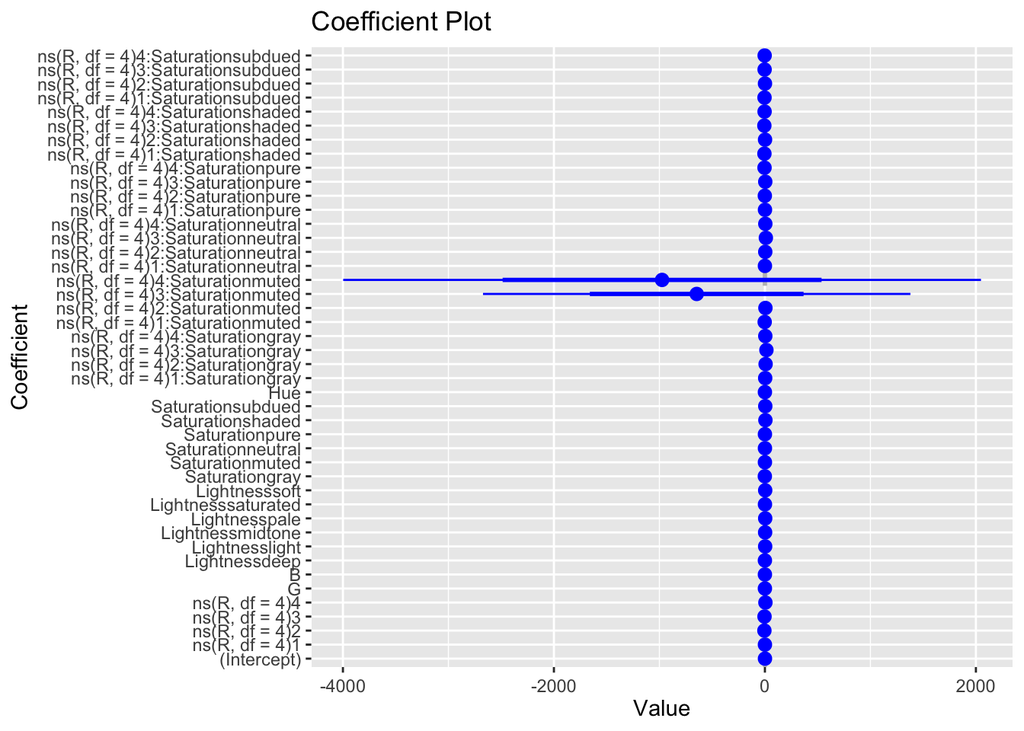

```r
coefplot::coefplot(mod10)
```

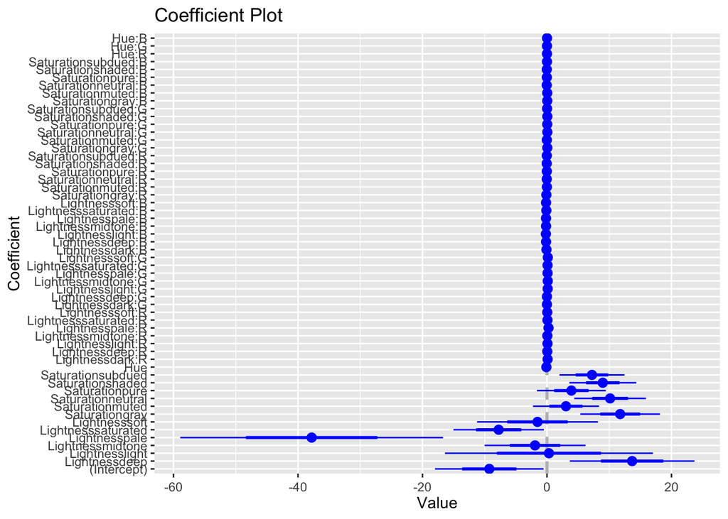

```r
coefplot::coefplot(mod7)
```

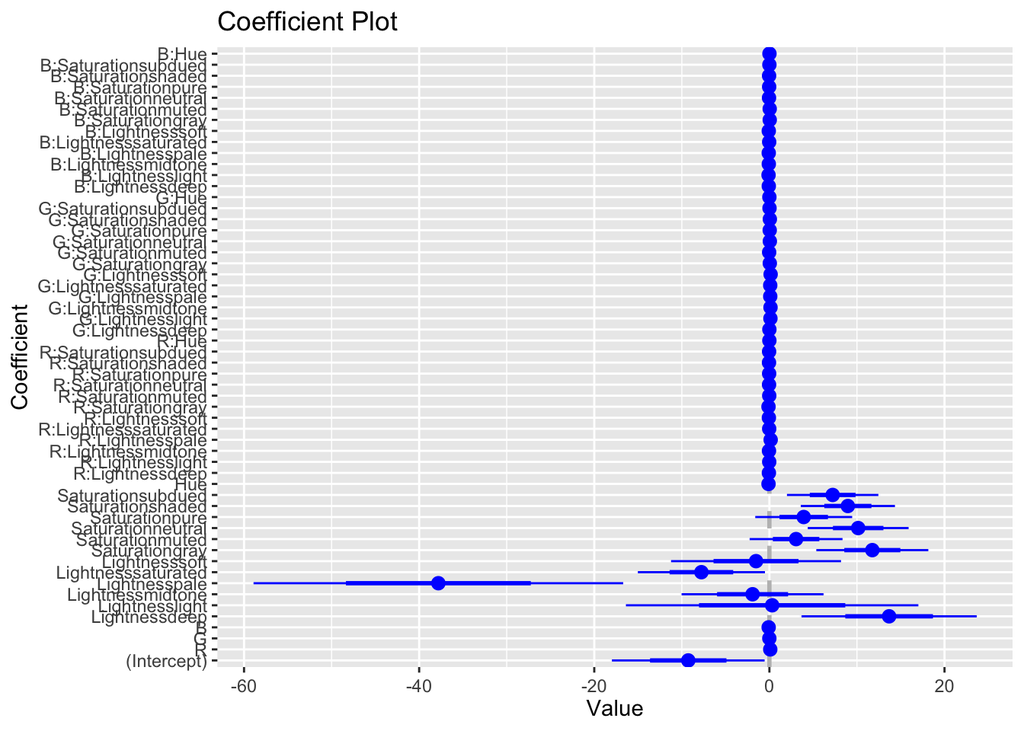

```r
coefplot::coefplot(mod6)
```

## Bayesian models

best model

```r
set.seed(432123)
mod7_bayesian <- stan_glm(outcome ~ Lightness + Saturation + Hue + Lightness:R + Lightness:G + Lightness:B + Saturation:R + Saturation:G + Saturation:B + Hue:R + Hue:G + Hue:B, data = dfiiiA)
mod7_bayesian %>% summary()
```

```
##
## Model Info:
##  function:     stan_glm
##  family:       gaussian [identity]
##  formula:      outcome ~ Lightness + Saturation + Hue + Lightness:R + Lightness:G +
##     Lightness:B + Saturation:R + Saturation:G + Saturation:B +
##     Hue:R + Hue:G + Hue:B
##  algorithm:    sampling
##  sample:       4000 (posterior sample size)
##  priors:       see help('prior_summary')
##  observations: 835
##  predictors:   56
##
## Estimates:
##                        mean   sd   10%   50%   90%
## (Intercept)           0.2    0.4 -0.3   0.2   0.7
## Lightnessdeep         0.3    0.3 -0.1   0.3   0.7
## Lightnesslight        0.5    0.8 -0.6   0.5   1.5
## Lightnessmidtone     -0.1    0.5 -0.6  -0.1   0.5
## Lightnesspale        -3.4    1.1 -4.8  -3.4  -2.0
## Lightnesssaturated   -1.0    0.4 -1.5  -1.0  -0.5
## Lightnesssoft         0.2    0.6 -0.6   0.2   0.9
## Saturationgray        0.7    0.2  0.4   0.7   1.0
## Saturationmuted       0.2    0.2  0.0   0.2   0.5
## Saturationneutral     0.3    0.2  0.1   0.3   0.6
## Saturationpure        0.3    0.2  0.0   0.3   0.6
## Saturationshaded      0.4    0.2  0.1   0.4   0.6
## Saturationsubdued     0.4    0.2  0.1   0.4   0.6
## Hue                   0.0    0.0  0.0   0.0   0.0
## Lightnessdark:R       0.0    0.0  0.0   0.0   0.0
## Lightnessdeep:R       0.0    0.0  0.0   0.0   0.0
## Lightnesslight:R      0.0    0.0  0.0   0.0   0.0
## Lightnessmidtone:R    0.0    0.0  0.0   0.0   0.0
## Lightnesspale:R       0.0    0.0  0.0   0.0   0.0
## Lightnesssaturated:R  0.0    0.0  0.0   0.0   0.0
## Lightnesssoft:R       0.0    0.0  0.0   0.0   0.0
## Lightnessdark:G       0.0    0.0  0.0   0.0   0.0
## Lightnessdeep:G       0.0    0.0  0.0   0.0   0.0
## Lightnesslight:G      0.0    0.0  0.0   0.0   0.0
## Lightnessmidtone:G    0.0    0.0  0.0   0.0   0.0
```

[output cut: 87 more lines]

```
## Saturationsubdued:G  0.0  1.0  1807
## Saturationgray:B     0.0  1.0  3024
## Saturationmuted:B    0.0  1.0  2475
## Saturationneutral:B  0.0  1.0  2928
## Saturationpure:B     0.0  1.0  1733
## Saturationshaded:B   0.0  1.0  2772
## Saturationsubdued:B  0.0  1.0  2186
## Hue:R                0.0  1.0  1180
## Hue:G                0.0  1.0   943
## Hue:B                0.0  1.0   964
## sigma                0.0  1.0  4720
## mean_PPD             0.0  1.0  4335
## log-posterior        0.1  1.0  1559
##
## For each parameter, mcse is Monte Carlo standard error, n_eff is a crude measure of effective sample size, and Rhat is the potential scale reduction factor on split chains (at convergence Rhat=1).
```

```r
posterior_interval(mod7_bayesian)
```

```
##                                 5%           95%
## (Intercept)          -3.880107e-01  8.041709e-01
## Lightnessdeep        -2.383836e-01  8.091816e-01
## Lightnesslight       -9.373000e-01  1.789253e+00
## Lightnessmidtone     -8.243094e-01  7.135072e-01
## Lightnesspale        -5.254079e+00 -1.567529e+00
## Lightnesssaturated   -1.593419e+00 -3.671695e-01
## Lightnesssoft        -7.649606e-01  1.060577e+00
## Saturationgray        2.905443e-01  1.040269e+00
## Saturationmuted      -5.363171e-02  5.487747e-01
## Saturationneutral    -3.893161e-03  6.505814e-01
## Saturationpure       -4.857853e-02  6.668244e-01
## Saturationshaded      6.647298e-02  6.910181e-01
## Saturationsubdued     4.940827e-02  6.572000e-01
## Hue                  -2.109429e-02  7.221269e-03
## Lightnessdark:R       1.073607e-03  7.323353e-03
## Lightnessdeep:R      -1.175620e-03  5.042721e-03
## Lightnesslight:R      4.094849e-05  9.414879e-03
## Lightnessmidtone:R   -1.672988e-03  4.729625e-03
## Lightnesspale:R       8.596675e-03  2.282205e-02
## Lightnesssaturated:R  1.941067e-04  6.417151e-03
## Lightnesssoft:R      -2.739888e-03  4.622908e-03
## Lightnessdark:G      -3.948458e-03  3.627378e-03
## Lightnessdeep:G      -2.255933e-03  5.641482e-03
## Lightnesslight:G     -3.453443e-03  1.029840e-02
## Lightnessmidtone:G    1.787683e-03  1.030820e-02
## Lightnesspale:G      -2.418783e-03  1.612618e-02
## Lightnesssaturated:G  2.049423e-03  9.889665e-03
## Lightnesssoft:G       7.222680e-04  1.115007e-02
## Lightnessdark:B      -1.120495e-02 -2.280391e-03
## Lightnessdeep:B      -1.276679e-02 -5.059501e-03
## Lightnesslight:B     -1.646968e-02 -7.451888e-03
## Lightnessmidtone:B   -1.280599e-02 -5.376344e-03
## Lightnesspale:B      -1.511673e-02 -3.446453e-03
## Lightnesssaturated:B -9.295248e-03 -1.674939e-03
## Lightnesssoft:B      -1.294877e-02 -5.247875e-03
## Saturationgray:R     -1.223359e-02  4.426677e-03
## Saturationmuted:R    -3.028659e-03  4.123207e-04
## Saturationneutral:R  -5.815128e-03  2.524061e-03
## Saturationpure:R     -2.320168e-03  4.728741e-04
## Saturationshaded:R   -6.238809e-03 -2.726882e-04
## Saturationsubdued:R  -3.916931e-03  5.191428e-04
## Saturationgray:G     -1.561449e-02  1.039621e-02
## Saturationmuted:G    -4.258094e-03  1.590804e-03
## Saturationneutral:G  -2.956541e-03  1.021149e-02
## Saturationpure:G     -2.103963e-03  2.808316e-03
## Saturationshaded:G   -2.368439e-03  7.454185e-03
## Saturationsubdued:G  -4.965491e-03  2.379596e-03
## Saturationgray:B     -1.130378e-04  1.583146e-02
## Saturationmuted:B    -3.011626e-04  3.814763e-03
## Saturationneutral:B  -5.765046e-03  2.125564e-03
## Saturationpure:B     -2.442706e-03  1.124775e-03
## Saturationshaded:B   -3.160264e-03  3.213577e-03
## Saturationsubdued:B  -1.929890e-04  4.738094e-03
## Hue:R                -2.985516e-04 -6.884247e-05
## Hue:G                -2.493839e-04  4.522266e-05
## Hue:B                 1.990081e-04  4.705108e-04
## sigma                 3.367985e-01  3.657393e-01
```

```r
rstanarm::bayes_R2(mod7_bayesian) %>% quantile(c(0.05, 0.5, 0.95))
```

```
##        5%       50%       95%
## 0.3150542 0.3539029 0.3912588
```

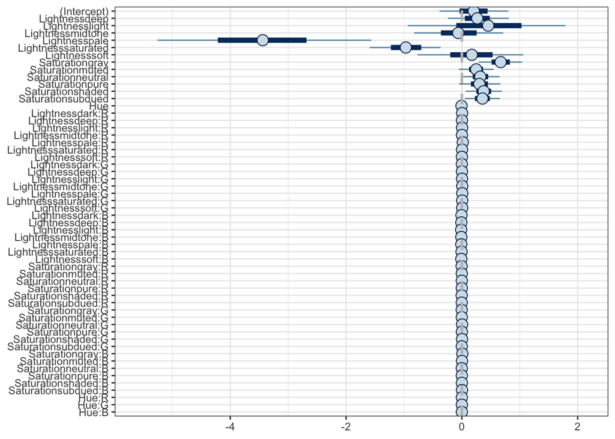

```r
plot(mod7_bayesian, pars = names(mod7_bayesian$coefficients)) +
  geom_vline(xintercept = 0, color = "grey", linetype = "dashed", size = 1.) +
  theme_bw()
```

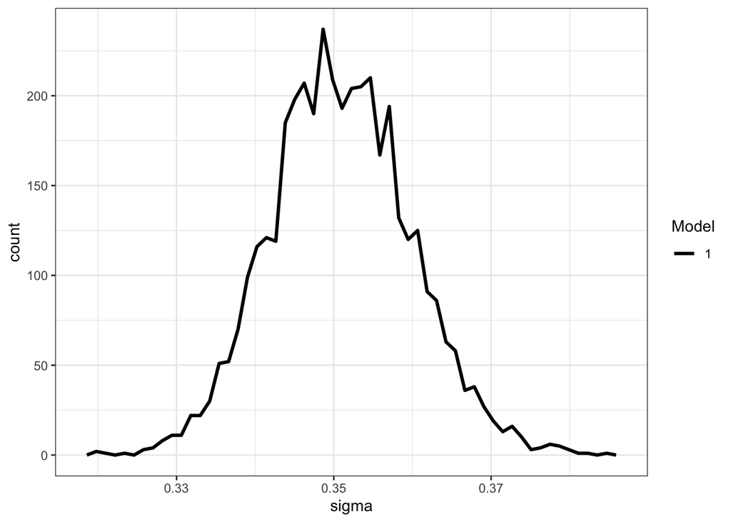

```r
purrr::map2_dfr(list(mod7_bayesian),
                as.character(1),
                function(mod, mod_name){as.data.frame(mod) %>% tibble::as_tibble() %>%
                    select(sigma) %>%
                    mutate(model_name = mod_name)}) %>%
  ggplot(mapping = aes(x = sigma)) +
  geom_freqpoly(bins = 55,
                 mapping = aes(color = model_name),
                 size = 1.1) +
  ggthemes::scale_color_colorblind("Model") +
  theme_bw()
```

The sigma is known and is almost normally distributed with a peak at 0.35.

```r
set.seed(432123)
mod10_bayesian <- stan_glm(outcome ~ ns(R, df = 4) + G + B + Lightness + Saturation + Hue + ns(R, df = 4):Saturation,
                 data = dfiiiA)
mod10_bayesian %>% summary()
```

```
##
## Model Info:
##  function:     stan_glm
##  family:       gaussian [identity]
##  formula:      outcome ~ ns(R, df = 4) + G + B + Lightness + Saturation + Hue +
##     ns(R, df = 4):Saturation
##  algorithm:    sampling
##  sample:       4000 (posterior sample size)
##  priors:       see help('prior_summary')
##  observations: 835
##  predictors:   44
##
## Estimates:
##                                    mean   sd   10%   50%   90%
## (Intercept)                       0.4    0.2  0.2   0.4   0.7
## ns(R, df = 4)1                    0.0    0.2 -0.3   0.0   0.2
## ns(R, df = 4)2                   -0.2    0.2 -0.4  -0.2   0.0
## ns(R, df = 4)3                   -0.3    0.4 -0.9  -0.3   0.3
## ns(R, df = 4)4                    0.2    0.2 -0.1   0.2   0.5
## G                                 0.0    0.0  0.0   0.0   0.0
## B                                 0.0    0.0  0.0   0.0   0.0
## Lightnessdeep                     0.0    0.1 -0.1   0.0   0.1
## Lightnesslight                    0.3    0.1  0.1   0.3   0.4
## Lightnessmidtone                  0.2    0.1  0.1   0.2   0.4
## Lightnesspale                     0.3    0.1  0.1   0.3   0.5
## Lightnesssaturated                0.1    0.1  0.0   0.1   0.2
## Lightnesssoft                     0.3    0.1  0.1   0.3   0.5
## Saturationgray                    0.1    0.8 -0.9   0.1   1.1
## Saturationmuted                   0.1    0.2 -0.2   0.1   0.4
## Saturationneutral                 0.3    0.4 -0.3   0.3   0.8
## Saturationpure                    0.0    0.2 -0.3   0.0   0.3
## Saturationshaded                  1.0    0.4  0.6   1.0   1.5
## Saturationsubdued                 0.8    0.3  0.4   0.8   1.2
## Hue                               0.0    0.0  0.0   0.0   0.0
## ns(R, df = 4)1:Saturationgray     0.5    0.7 -0.4   0.5   1.4
## ns(R, df = 4)2:Saturationgray     0.5    0.6 -0.2   0.5   1.3
## ns(R, df = 4)3:Saturationgray     1.5    1.7 -0.6   1.5   3.8
## ns(R, df = 4)4:Saturationgray     0.7    0.6 -0.1   0.7   1.5
## ns(R, df = 4)1:Saturationmuted   -0.1    0.3 -0.5  -0.1   0.2
## ns(R, df = 4)2:Saturationmuted   -0.1    0.2 -0.4  -0.1   0.2
```

[output cut: 62 more lines]

```
## ns(R, df = 4)3:Saturationpure    0.0  1.0  1616
## ns(R, df = 4)4:Saturationpure    0.0  1.0  2531
## ns(R, df = 4)1:Saturationshaded  0.0  1.0  2184
## ns(R, df = 4)2:Saturationshaded  0.0  1.0  1925
## ns(R, df = 4)3:Saturationshaded  0.0  1.0  1957
## ns(R, df = 4)4:Saturationshaded  0.0  1.0  3226
## ns(R, df = 4)1:Saturationsubdued 0.0  1.0  1741
## ns(R, df = 4)2:Saturationsubdued 0.0  1.0  1916
## ns(R, df = 4)3:Saturationsubdued 0.0  1.0  1603
## ns(R, df = 4)4:Saturationsubdued 0.0  1.0  3638
## sigma                            0.0  1.0  7210
## mean_PPD                         0.0  1.0  5396
## log-posterior                    0.1  1.0  1328
##
## For each parameter, mcse is Monte Carlo standard error, n_eff is a crude measure of effective sample size, and Rhat is the potential scale reduction factor on split chains (at convergence Rhat=1).
```

```r
posterior_interval(mod10_bayesian)
```

```
##                                             5%           95%
## (Intercept)                       0.0831283166  0.7470406845
## ns(R, df = 4)1                   -0.3608122791  0.2812839604
## ns(R, df = 4)2                   -0.4943281993  0.0885088691
## ns(R, df = 4)3                   -1.0433897505  0.4296247721
## ns(R, df = 4)4                   -0.1734722132  0.5969155676
## G                                -0.0029499215 -0.0004932131
## B                                -0.0019715484  0.0003649367
## Lightnessdeep                    -0.1065110093  0.0798210742
## Lightnesslight                    0.0195444045  0.4834527792
## Lightnessmidtone                  0.0477862213  0.3999154920
## Lightnesspale                     0.0428587013  0.5380797015
## Lightnesssaturated               -0.0676508096  0.1859948427
## Lightnesssoft                     0.0888621347  0.5066582524
## Saturationgray                   -1.2015727107  1.4211587065
## Saturationmuted                  -0.3176941098  0.5106204580
## Saturationneutral                -0.4056092009  0.9354949270
## Saturationpure                   -0.3937421398  0.3555716771
## Saturationshaded                  0.4472221237  1.6341543605
## Saturationsubdued                 0.2658773982  1.3040602039
## Hue                              -0.0005112966  0.0057944203
## ns(R, df = 4)1:Saturationgray    -0.6596823862  1.6826505823
## ns(R, df = 4)2:Saturationgray    -0.4601191786  1.5377573129
## ns(R, df = 4)3:Saturationgray    -1.2771313312  4.3871761787
## ns(R, df = 4)4:Saturationgray    -0.3399690367  1.7564150353
## ns(R, df = 4)1:Saturationmuted   -0.5707789593  0.2905985040
## ns(R, df = 4)2:Saturationmuted   -0.5250147405  0.2532051548
## ns(R, df = 4)3:Saturationmuted   -1.0394605063  0.9933905493
## ns(R, df = 4)4:Saturationmuted   -0.8905729990  0.1843279086
## ns(R, df = 4)1:Saturationneutral -0.6100259172  0.6295153073
## ns(R, df = 4)2:Saturationneutral -0.7324594389  0.3841811648
## ns(R, df = 4)3:Saturationneutral -0.5306342025  2.5357466901
## ns(R, df = 4)4:Saturationneutral  0.8642709563  2.4215934169
## ns(R, df = 4)1:Saturationpure    -0.2503217771  0.6081120449
## ns(R, df = 4)2:Saturationpure    -0.5418859529  0.1879029643
## ns(R, df = 4)3:Saturationpure    -0.4788052626  1.4215739365
## ns(R, df = 4)4:Saturationpure    -0.6073980494  0.2574174811
## ns(R, df = 4)1:Saturationshaded  -1.4281158382 -0.3084727021
## ns(R, df = 4)2:Saturationshaded  -1.0227347759 -0.0091056235
## ns(R, df = 4)3:Saturationshaded  -3.0156645465 -0.2708129042
## ns(R, df = 4)4:Saturationshaded  -0.5267699376  0.7419136869
## ns(R, df = 4)1:Saturationsubdued -1.1874234916 -0.1614360385
## ns(R, df = 4)2:Saturationsubdued -0.9710510904 -0.0548423261
## ns(R, df = 4)3:Saturationsubdued -2.3771331326  0.0831145185
## ns(R, df = 4)4:Saturationsubdued -0.4692539651  0.7171230168
## sigma                             0.3458473355  0.3745920505
```

```r
rstanarm::bayes_R2(mod10_bayesian) %>% quantile(c(0.05, 0.5, 0.95))
```

```
##        5%       50%       95%
## 0.2787254 0.3176596 0.3547909
```

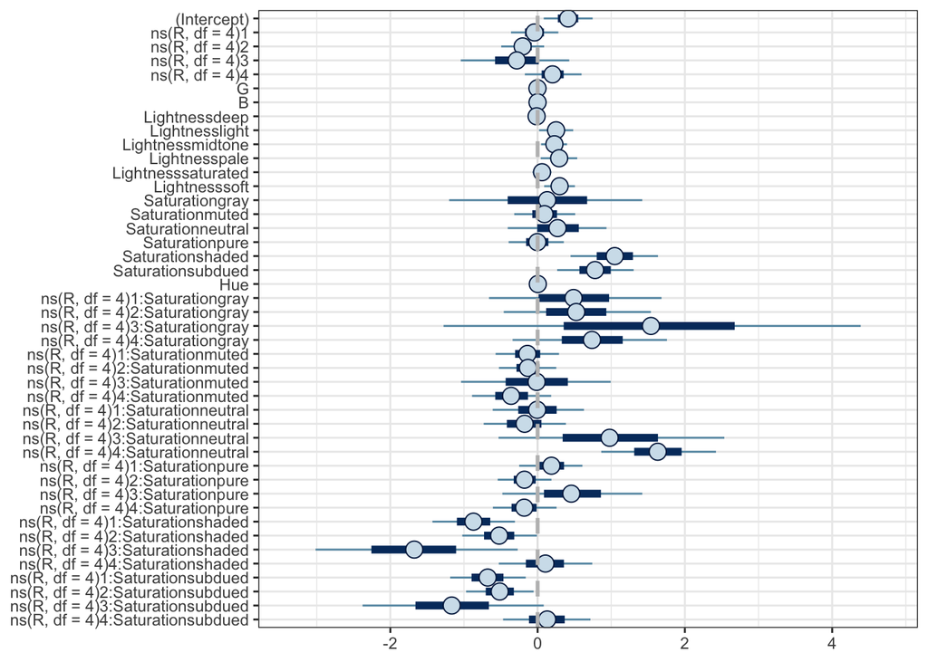

```r
plot(mod10_bayesian, pars = names(mod10_bayesian$coefficients)) +
  geom_vline(xintercept = 0, color = "grey", linetype = "dashed", size = 1.) +
  theme_bw()
```

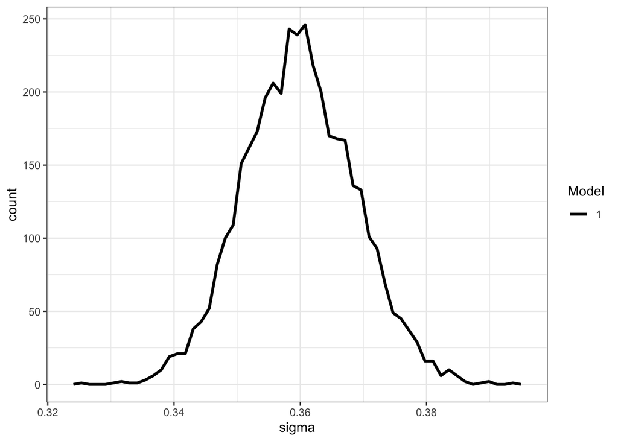

```r
purrr::map2_dfr(list(mod10_bayesian),
                as.character(1),
                function(mod, mod_name){as.data.frame(mod) %>% tibble::as_tibble() %>%
                    select(sigma) %>%
                    mutate(model_name = mod_name)}) %>%
  ggplot(mapping = aes(x = sigma)) +
  geom_freqpoly(bins = 55,
                 mapping = aes(color = model_name),
                 size = 1.1) +
  ggthemes::scale_color_colorblind("Model") +
  theme_bw()
```

The sigma is known and is almost normally distributed with a peak at 0.36.

```r
dfiiiD <- df %>%
  select(-response) %>%
  mutate(outcome = ifelse(outcome == 1, 'event', 'non_event'),
         outcome = factor(outcome, levels = c('event', 'non_event')))

dfiiiD %>% glimpse()
```

```
## Rows: 835
## Columns: 7
## $ R          <dbl> 172, 26, 172, 28, 170, 175, 90, 194, 171, 122, 0, 88, 144, …
## $ G          <dbl> 58, 88, 94, 87, 66, 89, 78, 106, 68, 151, 121, 140, 82, 163…
## $ B          <dbl> 62, 151, 58, 152, 58, 65, 136, 53, 107, 59, 88, 58, 132, 50…
## $ Lightness  <chr> "dark", "dark", "dark", "dark", "dark", "dark", "dark", "da…
## $ Saturation <chr> "bright", "bright", "bright", "bright", "bright", "bright",…
## $ Hue        <dbl> 4, 31, 8, 32, 5, 6, 34, 10, 1, 21, 24, 22, 36, 16, 26, 12, …
## $ outcome    <fct> event, event, event, non_event, non_event, non_event, non_e…
```

```r
dfiiiD %>% pull(outcome) %>% levels()
```

```
## [1] "event"     "non_event"
```

```r
dfiiiD %>% count(outcome)
```

```
## # A tibble: 2 × 2
##   outcome       n
##   <fct>     <int>
## 1 event       191
## 2 non_event   644
```

linear additive features

```r
set.seed(1024)

fit_lm_add <- train(outcome ~ Lightness + Saturation + Hue,
                  data = dfiiiD,
                  method = "glmnet",
                  metric = metric_roc,
                  trControl = ctrl_roc,
                  preProcess = c("center", "scale"),
                  family = "binomial")

fit_lm_add
```

```
## glmnet
##
## 835 samples
##   3 predictor
##   2 classes: 'event', 'non_event'
##
## Pre-processing: centered (13), scaled (13)
## Resampling: Cross-Validated (5 fold, repeated 3 times)
## Summary of sample sizes: 668, 668, 669, 668, 667, 668, ...
## Resampling results across tuning parameters:
##
##   alpha  lambda        ROC        Sens       Spec
##   0.10   0.0003523518  0.7695208  0.3350427  0.9647933
##   0.10   0.0035235183  0.7687897  0.3315340  0.9678981
##   0.10   0.0352351830  0.7589524  0.3297796  0.9689357
##   0.55   0.0003523518  0.7695344  0.3350427  0.9647933
##   0.55   0.0035235183  0.7696727  0.3315340  0.9684149
##   0.55   0.0352351830  0.7492455  0.3297796  0.9689357
##   1.00   0.0003523518  0.7695005  0.3350427  0.9647933
##   1.00   0.0035235183  0.7707048  0.3297796  0.9689357
##   1.00   0.0352351830  0.7230588  0.3297796  0.9689357
##
## ROC was used to select the optimal model using the largest value.
## The final values used for the model were alpha = 1 and lambda = 0.003523518.
```

All categorical and continuous variables - linear additive

```r
set.seed(1024)

fit_lm_add_der <- train(outcome ~ R + G + B + Lightness + Saturation + Hue,
                  data = dfiiiD,
                  method = "glmnet",
                  metric = metric_roc,
                  trControl = ctrl_roc,
                  preProcess = c("center", "scale"),
                  family = "binomial")

fit_lm_add_der
```

```
## glmnet
##
## 835 samples
##   6 predictor
##   2 classes: 'event', 'non_event'
##
## Pre-processing: centered (16), scaled (16)
## Resampling: Cross-Validated (5 fold, repeated 3 times)
## Summary of sample sizes: 668, 668, 669, 668, 667, 668, ...
## Resampling results across tuning parameters:
##
##   alpha  lambda        ROC        Sens       Spec
##   0.10   0.0003523518  0.7808797  0.3403059  0.9616885
##   0.10   0.0035235183  0.7795927  0.3385965  0.9622053
##   0.10   0.0352351830  0.7707694  0.3281152  0.9689357
##   0.55   0.0003523518  0.7804966  0.3385515  0.9616885
##   0.55   0.0035235183  0.7788919  0.3403059  0.9647933
##   0.55   0.0352351830  0.7565249  0.3297796  0.9689357
##   1.00   0.0003523518  0.7801303  0.3385515  0.9616885
##   1.00   0.0035235183  0.7779000  0.3385065  0.9663437
##   1.00   0.0352351830  0.7246960  0.3297796  0.9689357
##
## ROC was used to select the optimal model using the largest value.
## The final values used for the model were alpha = 0.1 and lambda = 0.0003523518.
```

All pairwise interactions of continuous inputs

```r
set.seed(1024)

fit_lm_pair <- train(outcome ~ R + G + B + Lightness + Saturation + Hue + R:Lightness + R:Saturation + R:Hue + G:Lightness + G:Saturation + G:Hue + B:Lightness + B:Saturation + B:Hue,
                  data = dfiiiD,
                  method = "glmnet",
                  metric = metric_roc,
                  trControl = ctrl_roc,
                  preProcess = c("center", "scale"),
                  family = "binomial")

fit_lm_pair
```

```
## glmnet
##
## 835 samples
##   6 predictor
##   2 classes: 'event', 'non_event'
##
## Pre-processing: centered (55), scaled (55)
## Resampling: Cross-Validated (5 fold, repeated 3 times)
## Summary of sample sizes: 668, 668, 669, 668, 667, 668, ...
## Resampling results across tuning parameters:
##
##   alpha  lambda        ROC        Sens       Spec
##   0.10   0.0003534478  0.8228803  0.3631129  0.9399548
##   0.10   0.0035344779  0.7996324  0.3368871  0.9580467
##   0.10   0.0353447789  0.7856317  0.3211426  0.9689357
##   0.55   0.0003534478  0.8261869  0.3753486  0.9363251
##   0.55   0.0035344779  0.7888524  0.3246514  0.9601179
##   0.55   0.0353447789  0.7739132  0.3246514  0.9689357
##   1.00   0.0003534478  0.8324744  0.3964013  0.9254683
##   1.00   0.0035344779  0.7857875  0.3211426  0.9632267
##   1.00   0.0353447789  0.7513738  0.3125956  0.9694525
##
## ROC was used to select the optimal model using the largest value.
## The final values used for the model were alpha = 1 and lambda = 0.0003534478.
```

```r
set.seed(1024)

fit_lm_3a <- train(outcome ~ Lightness + Saturation + Hue + Lightness:R + Lightness:G + Lightness:B + Saturation:R + Saturation:G + Saturation:B + Hue:R + Hue:G + Hue:B,
                  data = dfiiiD,
                  method = "glmnet",
                  metric = metric_roc,
                  trControl = ctrl_roc,
                  preProcess = c("center", "scale"),
                  family = "binomial")

fit_lm_3a
```

```
## glmnet
##
## 835 samples
##   6 predictor
##   2 classes: 'event', 'non_event'
##
## Pre-processing: centered (55), scaled (55)
## Resampling: Cross-Validated (5 fold, repeated 3 times)
## Summary of sample sizes: 668, 668, 669, 668, 667, 668, ...
## Resampling results across tuning parameters:
##
##   alpha  lambda        ROC        Sens       Spec
##   0.10   0.0003534478  0.8209249  0.3578048  0.9327075
##   0.10   0.0035344779  0.8058900  0.3351327  0.9564842
##   0.10   0.0353447789  0.7820540  0.3210526  0.9689398
##   0.55   0.0003534478  0.8228662  0.3735493  0.9337492
##   0.55   0.0035344779  0.7996720  0.3228970  0.9580426
##   0.55   0.0353447789  0.7650479  0.3195232  0.9689357
##   1.00   0.0003534478  0.8284816  0.3858300  0.9285691
##   1.00   0.0035344779  0.7954628  0.3193882  0.9606387
##   1.00   0.0353447789  0.7338151  0.3125956  0.9694525
##
## ROC was used to select the optimal model using the largest value.
## The final values used for the model were alpha = 1 and lambda = 0.0003534478.
```

Elastic net all pairwise

```r
set.seed(1024)
fit_enet_pair <- train(
  outcome ~ R + G + B + Lightness + Saturation + Hue + R:Lightness + R:Saturation + R:Hue + G:Lightness + G:Saturation + G:Hue + B:Lightness + B:Saturation + B:Hue,
  data = dfiiiD,
  method = "glmnet",
  metric = metric_roc,
  trControl = ctrl_roc,
  family = "binomial",
  preProcess = c('center', 'scale')
)
fit_enet_pair
```

```
## glmnet
##
## 835 samples
##   6 predictor
##   2 classes: 'event', 'non_event'
##
## Pre-processing: centered (55), scaled (55)
## Resampling: Cross-Validated (5 fold, repeated 3 times)
## Summary of sample sizes: 668, 668, 669, 668, 667, 668, ...
## Resampling results across tuning parameters:
##
##   alpha  lambda        ROC        Sens       Spec
##   0.10   0.0003534478  0.8228803  0.3631129  0.9399548
##   0.10   0.0035344779  0.7996324  0.3368871  0.9580467
##   0.10   0.0353447789  0.7856317  0.3211426  0.9689357
##   0.55   0.0003534478  0.8261869  0.3753486  0.9363251
##   0.55   0.0035344779  0.7888524  0.3246514  0.9601179
##   0.55   0.0353447789  0.7739132  0.3246514  0.9689357
##   1.00   0.0003534478  0.8324744  0.3964013  0.9254683
##   1.00   0.0035344779  0.7857875  0.3211426  0.9632267
##   1.00   0.0353447789  0.7513738  0.3125956  0.9694525
##
## ROC was used to select the optimal model using the largest value.
## The final values used for the model were alpha = 1 and lambda = 0.0003534478.
```

Elastic net 3a

```r
set.seed(1024)
fit_enet_3a <- train(
  outcome ~  Lightness + Saturation + Hue + Lightness:R + Lightness:G + Lightness:B + Saturation:R + Saturation:G + Saturation:B + Hue:R + Hue:G + Hue:B,
  data = dfiiiD,
  method = "glmnet",
  metric = metric_roc,
  trControl = ctrl_roc,
  family = "binomial",
  preProcess = c('center', 'scale')
)
fit_enet_3a
```

```
## glmnet
##
## 835 samples
##   6 predictor
##   2 classes: 'event', 'non_event'
##
## Pre-processing: centered (55), scaled (55)
## Resampling: Cross-Validated (5 fold, repeated 3 times)
## Summary of sample sizes: 668, 668, 669, 668, 667, 668, ...
## Resampling results across tuning parameters:
##
##   alpha  lambda        ROC        Sens       Spec
##   0.10   0.0003534478  0.8209249  0.3578048  0.9327075
##   0.10   0.0035344779  0.8058900  0.3351327  0.9564842
##   0.10   0.0353447789  0.7820540  0.3210526  0.9689398
##   0.55   0.0003534478  0.8228662  0.3735493  0.9337492
##   0.55   0.0035344779  0.7996720  0.3228970  0.9580426
##   0.55   0.0353447789  0.7650479  0.3195232  0.9689357
##   1.00   0.0003534478  0.8284816  0.3858300  0.9285691
##   1.00   0.0035344779  0.7954628  0.3193882  0.9606387
##   1.00   0.0353447789  0.7338151  0.3125956  0.9694525
##
## ROC was used to select the optimal model using the largest value.
## The final values used for the model were alpha = 1 and lambda = 0.0003534478.
```

Neural network base

```r
set.seed(1024)
fit_cls_nnet_b <- train(
  outcome ~ Lightness + Saturation + Hue,
  data = dfiiiD,
  method = "nnet",
  metric = metric_roc,
  trControl = ctrl_roc,
  family = "binomial",
  preProcess = c('center', 'scale')
)
fit_cls_nnet_b
```

```
## Neural Network
##
## 835 samples
##   3 predictor
##   2 classes: 'event', 'non_event'
##
## Pre-processing: centered (13), scaled (13)
## Resampling: Cross-Validated (5 fold, repeated 3 times)
## Summary of sample sizes: 668, 668, 669, 668, 667, 668, ...
## Resampling results across tuning parameters:
##
##   size  decay  ROC        Sens       Spec
##   1     0e+00  0.7271737  0.2146199  0.9756702
##   1     1e-04  0.7373677  0.2531264  0.9565488
##   1     1e-01  0.7671280  0.3350427  0.9637557
##   3     0e+00  0.7718171  0.4214575  0.9187863
##   3     1e-04  0.7771836  0.4275304  0.9120195
##   3     1e-01  0.8190542  0.4539811  0.9327318
##   5     0e+00  0.7781834  0.4819163  0.9068112
##   5     1e-04  0.7771637  0.5113360  0.8820050
##   5     1e-01  0.8219786  0.4820063  0.9187217
##
## ROC was used to select the optimal model using the largest value.
## The final values used for the model were size = 5 and decay = 0.1.
```

Neural net derived

```r
set.seed(1024)
fit_cls_nnet_d <- train(
  outcome ~ R + G + B + Lightness + Saturation + Hue,
  data = dfiiiD,
  method = "nnet",
  metric = metric_roc,
  trControl = ctrl_roc,
  family = "binomial",
  preProcess = c('center', 'scale')
)
fit_cls_nnet_d
```

```
## Neural Network
##
## 835 samples
##   6 predictor
##   2 classes: 'event', 'non_event'
##
## Pre-processing: centered (16), scaled (16)
## Resampling: Cross-Validated (5 fold, repeated 3 times)
## Summary of sample sizes: 668, 668, 669, 668, 667, 668, ...
## Resampling results across tuning parameters:
##
##   size  decay  ROC        Sens       Spec
##   1     0e+00  0.7371908  0.3415205  0.9326147
##   1     1e-04  0.7465900  0.2572200  0.9482760
##   1     1e-01  0.7800200  0.3682411  0.9497901
##   3     0e+00  0.7961377  0.5289249  0.8778747
##   3     1e-04  0.8164028  0.5444444  0.9058220
##   3     1e-01  0.8464410  0.5463788  0.9197836
##   5     0e+00  0.7957738  0.5253711  0.8907138
##   5     1e-04  0.7902568  0.5284750  0.8835917
##   5     1e-01  0.8394776  0.5185785  0.9192628
##
## ROC was used to select the optimal model using the largest value.
## The final values used for the model were size = 3 and decay = 0.1.
```

Random forest base

```r
set.seed(1024)

fit_cls_rf_b <- train(outcome ~ Lightness + Saturation + Hue,
                 data = dfiiiD,
                 method = "rf",
                 metric = metric_roc,
                 trControl = ctrl_roc,
                 family = "binomial",
                 preProcess = c('center', 'scale'),
                 importance = TRUE
                 )

fit_cls_rf_b
```

```
## Random Forest
##
## 835 samples
##   3 predictor
##   2 classes: 'event', 'non_event'
##
## Pre-processing: centered (13), scaled (13)
## Resampling: Cross-Validated (5 fold, repeated 3 times)
## Summary of sample sizes: 668, 668, 669, 668, 667, 668, ...
## Resampling results across tuning parameters:
##
##   mtry  ROC        Sens       Spec
##    2    0.8398046  0.3158794  0.9715197
##    7    0.8794977  0.5391363  0.9358083
##   13    0.8658947  0.5670265  0.9052649
##
## ROC was used to select the optimal model using the largest value.
## The final value used for the model was mtry = 7.
```

Random forest derived

```r
set.seed(1024)

fit_cls_rf_d <- train(outcome ~ R + G + B + Lightness + Saturation + Hue,
                 data = dfiiiD,
                 method = "rf",
                 metric = metric_roc,
                 trControl = ctrl_roc,
                 family = "binomial",
                 preProcess = c('center', 'scale'),
                 importance = TRUE
                 )

fit_cls_rf_d
```

```
## Random Forest
##
## 835 samples
##   6 predictor
##   2 classes: 'event', 'non_event'
##
## Pre-processing: centered (16), scaled (16)
## Resampling: Cross-Validated (5 fold, repeated 3 times)
## Summary of sample sizes: 668, 668, 669, 668, 667, 668, ...
## Resampling results across tuning parameters:
##
##   mtry  ROC        Sens       Spec
##    2    0.8621262  0.3297346  0.9735950
##    9    0.8908760  0.5724696  0.9373708
##   16    0.8867053  0.6020693  0.9327116
##
## ROC was used to select the optimal model using the largest value.
## The final value used for the model was mtry = 9.
```

XGB base

```r
set.seed(1024)

fit_cls_xgb_b <- train(outcome ~ Lightness + Saturation + Hue,
                 data = dfiiiD,
                 method = "xgbTree",
                 metric = metric_roc,
                 trControl = ctrl_roc,
                 family = "binomial",
                 preProcess = c('center', 'scale'),
                 verbosity = 0)

fit_cls_xgb_b
```

```
## eXtreme Gradient Boosting
##
## 835 samples
##   3 predictor
##   2 classes: 'event', 'non_event'
##
## Pre-processing: centered (13), scaled (13)
## Resampling: Cross-Validated (5 fold, repeated 3 times)
## Summary of sample sizes: 668, 668, 669, 668, 667, 668, ...
## Resampling results across tuning parameters:
##
##   eta  max_depth  colsample_bytree  subsample  nrounds  ROC        Sens
##   0.3  1          0.6               0.50        50      0.8253218  0.3472785
##   0.3  1          0.6               0.50       100      0.8375293  0.4099415
##   0.3  1          0.6               0.50       150      0.8390319  0.4394962
##   0.3  1          0.6               0.75        50      0.8317077  0.3349978
##   0.3  1          0.6               0.75       100      0.8390437  0.4065227
##   0.3  1          0.6               0.75       150      0.8455781  0.4483131
##   0.3  1          0.6               1.00        50      0.8314037  0.3228070
##   0.3  1          0.6               1.00       100      0.8451956  0.3771480
##   0.3  1          0.6               1.00       150      0.8462575  0.4221323
##   0.3  1          0.8               0.50        50      0.8329344  0.3490778
##   0.3  1          0.8               0.50       100      0.8394358  0.4291048
##   0.3  1          0.8               0.50       150      0.8455567  0.4431849
##   0.3  1          0.8               0.75        50      0.8332884  0.3384166
##   0.3  1          0.8               0.75       100      0.8432237  0.4238417
##   0.3  1          0.8               0.75       150      0.8461374  0.4554206
##   0.3  1          0.8               1.00        50      0.8361616  0.3280252
##   0.3  1          0.8               1.00       100      0.8452851  0.3839406
##   0.3  1          0.8               1.00       150      0.8470860  0.4273954
##   0.3  2          0.6               0.50        50      0.8398668  0.4203329
##   0.3  2          0.6               0.50       100      0.8515296  0.4903284
##   0.3  2          0.6               0.50       150      0.8572573  0.5322987
##   0.3  2          0.6               0.75        50      0.8481797  0.4327036
##   0.3  2          0.6               0.75       100      0.8565800  0.4868196
##   0.3  2          0.6               0.75       150      0.8592247  0.5201080
##   0.3  2          0.6               1.00        50      0.8468253  0.4133603
##   0.3  2          0.6               1.00       100      0.8543020  0.4746739
##   0.3  2          0.6               1.00       150      0.8607803  0.4991003
##   0.3  2          0.8               0.50        50      0.8507767  0.4621682
```

[output cut: 182 more lines]

```
##   0.9197997
##   0.9389293
##   0.9249717
##   0.9254845
##   0.9446463
##   0.9296471
##   0.9275719
##
## Tuning parameter 'gamma' was held constant at a value of 0
## Tuning
##  parameter 'min_child_weight' was held constant at a value of 1
## ROC was used to select the optimal model using the largest value.
## The final values used for the model were nrounds = 150, max_depth = 3, eta
##  = 0.4, gamma = 0, colsample_bytree = 0.8, min_child_weight = 1 and subsample
##  = 1.
```

XGB derived

```r
set.seed(1024)

fit_cls_xgb_d <- train(outcome ~ R + G + B + Lightness + Saturation + Hue,
                 data = dfiiiD,
                 method = "xgbTree",
                 metric = metric_roc,
                 trControl = ctrl_roc,
                 family = "binomial",
                 preProcess = c('center', 'scale'),
                 verbosity = 0)

fit_cls_xgb_d
```

```
## eXtreme Gradient Boosting
##
## 835 samples
##   6 predictor
##   2 classes: 'event', 'non_event'
##
## Pre-processing: centered (16), scaled (16)
## Resampling: Cross-Validated (5 fold, repeated 3 times)
## Summary of sample sizes: 668, 668, 669, 668, 667, 668, ...
## Resampling results across tuning parameters:
##
##   eta  max_depth  colsample_bytree  subsample  nrounds  ROC        Sens
##   0.3  1          0.6               0.50        50      0.8435451  0.3769231
##   0.3  1          0.6               0.50       100      0.8623815  0.4657670
##   0.3  1          0.6               0.50       150      0.8733244  0.4937922
##   0.3  1          0.6               0.75        50      0.8474683  0.3733243
##   0.3  1          0.6               0.75       100      0.8657784  0.4466037
##   0.3  1          0.6               0.75       150      0.8751094  0.4955466
##   0.3  1          0.6               1.00        50      0.8537415  0.3629330
##   0.3  1          0.6               1.00       100      0.8691696  0.4048583
##   0.3  1          0.6               1.00       150      0.8741615  0.4553756
##   0.3  1          0.8               0.50        50      0.8488265  0.3681961
##   0.3  1          0.8               0.50       100      0.8631062  0.4641925
##   0.3  1          0.8               0.50       150      0.8663397  0.5008997
##   0.3  1          0.8               0.75        50      0.8498649  0.3663518
##   0.3  1          0.8               0.75       100      0.8699421  0.4482681
##   0.3  1          0.8               0.75       150      0.8725043  0.4921278
##   0.3  1          0.8               1.00        50      0.8556753  0.3664417
##   0.3  1          0.8               1.00       100      0.8702869  0.3978857
##   0.3  1          0.8               1.00       150      0.8742107  0.4587494
##   0.3  2          0.6               0.50        50      0.8751751  0.4989654
##   0.3  2          0.6               0.50       100      0.8797815  0.5514620
##   0.3  2          0.6               0.50       150      0.8807015  0.5758435
##   0.3  2          0.6               0.75        50      0.8816179  0.5024741
##   0.3  2          0.6               0.75       100      0.8855338  0.5740441
##   0.3  2          0.6               0.75       150      0.8869637  0.5864148
##   0.3  2          0.6               1.00        50      0.8793312  0.4937472
##   0.3  2          0.6               1.00       100      0.8847646  0.5688259
##   0.3  2          0.6               1.00       150      0.8859190  0.5705353
##   0.3  2          0.8               0.50        50      0.8845029  0.5112910
```

[output cut: 182 more lines]

```
##   0.9197876
##   0.9270308
##   0.9213582
##   0.9229046
##   0.9342821
##   0.9280644
##   0.9223716
##
## Tuning parameter 'gamma' was held constant at a value of 0
## Tuning
##  parameter 'min_child_weight' was held constant at a value of 1
## ROC was used to select the optimal model using the largest value.
## The final values used for the model were nrounds = 100, max_depth = 3, eta
##  = 0.3, gamma = 0, colsample_bytree = 0.8, min_child_weight = 1 and subsample
##  = 0.75.
```

SVM

```r
set.seed(1024)

fit_cls_svm <- train(outcome ~ Lightness + Saturation + Hue,
                 data = dfiiiD,
                 method = "svmRadial",
                 metric = metric_roc,
                 trControl = ctrl_roc,
                 family = "binomial",
                 preProcess = c('center', 'scale')
                 )

fit_cls_svm
```

```
## Support Vector Machines with Radial Basis Function Kernel
##
## 835 samples
##   3 predictor
##   2 classes: 'event', 'non_event'
##
## Pre-processing: centered (13), scaled (13)
## Resampling: Cross-Validated (5 fold, repeated 3 times)
## Summary of sample sizes: 668, 668, 669, 668, 667, 668, ...
## Resampling results across tuning parameters:
##
##   C     ROC        Sens       Spec
##   0.25  0.7133363  0.3297796  0.9689357
##   0.50  0.7202345  0.3297796  0.9689357
##   1.00  0.7330648  0.3297796  0.9689357
##
## Tuning parameter 'sigma' was held constant at a value of 0.0459679
## ROC was used to select the optimal model using the largest value.
## The final values used for the model were sigma = 0.0459679 and C = 1.
```

## Comparision

```r
my_results <- resamples(list(LM_b = fit_lm_add,
                             LM_d = fit_lm_add_der,
                             LM_p = fit_lm_pair,
                             LM_3a = fit_lm_3a,

                             ENET_3a = fit_enet_3a,
                             ENET_pair = fit_enet_pair,

                             SVM = fit_cls_svm,

                             NNET_b = fit_cls_nnet_b,
                             NNET_d = fit_cls_nnet_d,

                             RF_b = fit_cls_rf_b,
                             RF_d = fit_cls_rf_d,

                             XGB_b = fit_cls_xgb_b,
                             XGB_d = fit_cls_xgb_d))
```

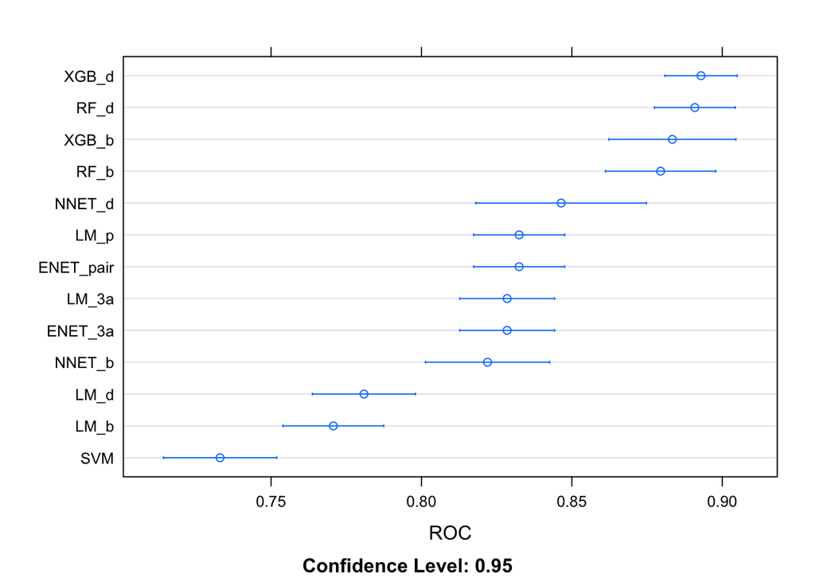

```r
dotplot(my_results, metric = "ROC")
```

## Variable importance

```r
varImp(fit_cls_xgb_d)
```

```
## xgbTree variable importance
##
##                     Overall
## Hue                100.0000
## Saturationgray      57.6122
## B                   55.8944
## R                   53.6775
## G                   48.1601
## Saturationneutral   12.0945
## Saturationmuted      5.8628
## Saturationshaded     4.2111
## Lightnesspale        3.0656
## Saturationpure       1.7895
## Lightnesssoft        1.7638
## Lightnessmidtone     1.6840
## Lightnessdeep        1.4679
## Saturationsubdued    0.9432
## Lightnesslight       0.7831
## Lightnesssaturated   0.0000
```

```r
fit_cls_xgb_d %>% readr::write_rds('my_best_cls_model.rds')
```